# Milestone Report 1

Denitsa Panova

July 31, 2017

# Executive Summary

The purpose of this paper is to compare three different text files. These files contain documents from English blogs, twits or news. Each line in the text files is a seperate document. Using text mining techniques, we investigate each file seperately because there is significant difference in the style of writing and the length of the documents between the three. We conclude that the most used words  
in blogs are:*one, will,like, time, just, can,get* (which also are the ones which are used next to each other);  
in twitter: *just,get,thank* (which are not usually used in the same twit);  
and in news: *said,will,year,one* (which are also not used often together).  
Therfore, the predict-your-next-word application which we will build will be primarely based on what text, the user will want to write: a blog,a twit or an article.

# Data

## Download Data

Let’s get the data from source.

```r
#set working directory
setwd('/Users/dpanova/Documents/Resources/DataScienceSpecialization/Capstone/')
temp = tempfile()
#download the file
download.file('https://d396qusza40orc.cloudfront.net/dsscapstone/dataset/Coursera-SwiftKey.zip',temp)
#unzip it
unzip(temp)
```

## Load the Data

If we already have the data, we can just navigate to the appropriate folder. To read in the text files and for the whole analysis will use **tx** package in R.  
Each of the files will be considered as a seperate corpus.

```r
#change working directory
new_working_directory = '/Users/dpanova/Documents/Resources/DataScienceSpecialization/Capstone/final/en_US/'
setwd(new_working_directory)
#list files
file_names = list.files(new_working_directory)
#read in all file names as a different corpus
library('tm')
corpus_files = list() #placeholder for the corpus names
for (f in file_names){
  temp = as.data.frame(readLines(f))
  corp = Corpus(DataframeSource(temp))
  corpus_files[[length(corpus_files)+1]] = temp
}
```

## Transform the Data

In order to do exploratory analysis, first we need to clean the data sets. The full transformation of the data sets is visible in the appendix - Data Transformation

# Exploratory Analysis

## Document Term Matrix

The exploratory analysis will be conducted on the document term matrix since it represent each line as a combination of words.

```r
dtm_files = list()
for(cname in corpus_files){
  temp = DocumentTermMatrix(cname)
  dtm_files[[length(dtm_files)+1]] = temp
}
```

## Basic Statistics

This section provides basic statistics for the three documents.

```r
basic_summary_table = as.data.frame(c())
for(i in dtm_files){
  dimenstions = dim(dtm_files[[i]])
  basic_summary_table = rbind(basic_summary_table,
                              dimenstions)
}
row.names(basic_summary_table) = c('Blog','Twitter','News')
colnames(basic_summary_table) = c('Number_of_lines','Number_of_unique_words')
```

```
##         Number_of_lines Number_of_unique_words
## Blog             300000                 393407
## Twitter          829087                 416781
## News              25354                  69373
```

## Graph Representation

This section provides three types of graphs for each file:  
1) Histogram of the most frequent terms (assumption:we exclude terms in order to make the document term matrix only 90% sparse)  
2) Word cloud of the most frequent terms (assumption:we exclude terms in order to make the document term matrix only 95% sparse)  
3) Hyrarchical clustering of the most frequent terms to identify connections between the terms  
The code is available in the appendix, Graph Representaion Code.

### Blogs

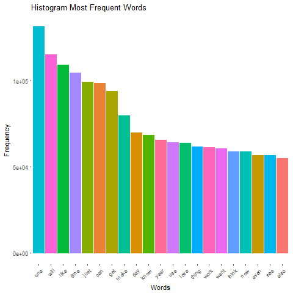

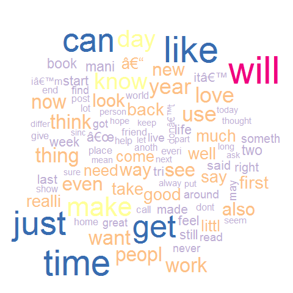

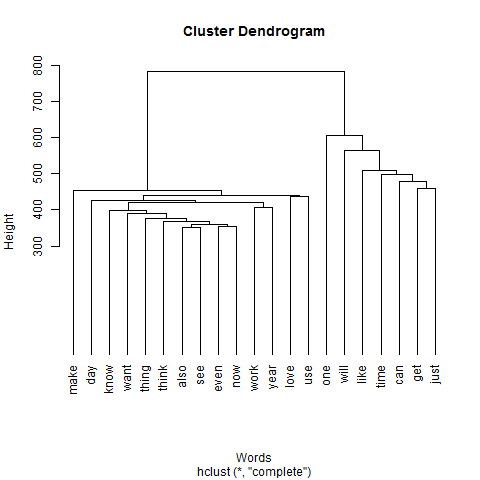

### Twitter

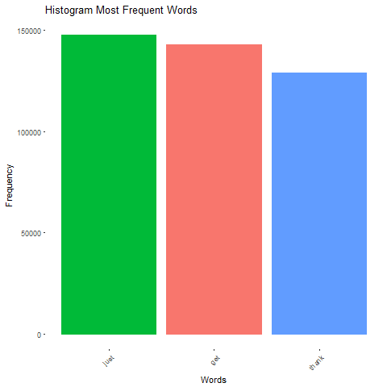

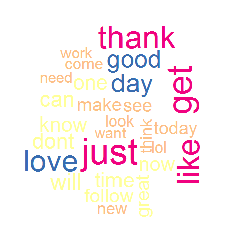

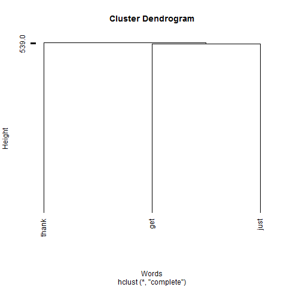

### News

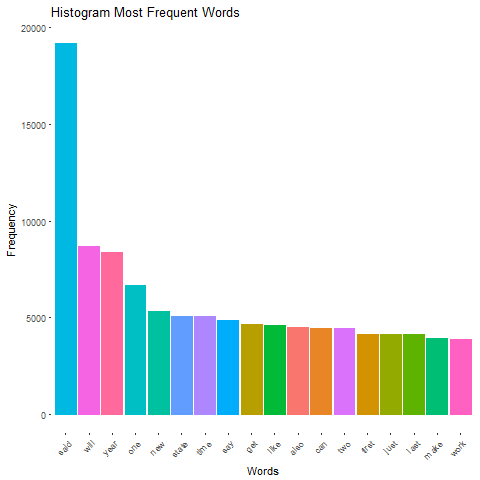

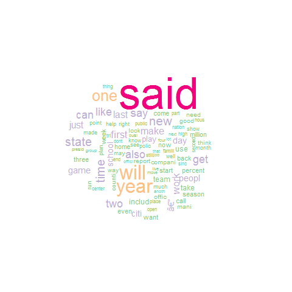

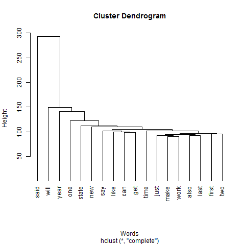

# References

- [TM Tutorial 1](http://onepager.togaware.com/TextMiningO.pdf)
- [TM Tutorial 2](https://rstudio-pubs-static.s3.amazonaws.com/265713_cbef910aee7642dc8b62996e38d2825d.html)

# Apendix

## Data Transformation

```r
for(i in length(corpus_files)){
  #Convert to lower case
  corpus_files[[i]] = tm_map(corpus_files[[i]], content_transformer(tolower))
  #save the file as a plain text for easier calculation
  corpus_files[[i]] = tm_map(corpus_files[[i]], PlainTextDocument)
  #Remove Numbers
  corpus_files[[i]] = tm_map(corpus_files[[i]], removeNumbers)
  corpus_files[[i]] = tm_map(corpus_files[[i]], PlainTextDocument)
  #remove Punctuation
  corpus_files[[i]] = tm_map(corpus_files[[i]] , removePunctuation)
  corpus_files[[i]] = tm_map(corpus_files[[i]], PlainTextDocument)
  #Remove Stopwords
  corpus_files[[i]] = tm_map(corpus_files[[i]] , removeWords, stopwords("english"))
  corpus_files[[i]] = tm_map(corpus_files[[i]], PlainTextDocument)
  #Remove white spaces
  corpus_files[[i]]  = tm_map(corpus_files[[i]] , stripWhitespace)
  corpus_files[[i]] = tm_map(corpus_files[[i]], PlainTextDocument)
  #Stem words
  corpus_files[[i]]  = tm_map(corpus_files[[i]], stemDocument)
  corpus_files[[i]] = tm_map(corpus_files[[i]], PlainTextDocument)
}
```

## Stopwords

```r
length(stopwords("english"))
```

```
## [1] 174
```

```r
head(stopwords("english"),30)
```

```
##  [1] "i"          "me"         "my"         "myself"     "we"
##  [6] "our"        "ours"       "ourselves"  "you"        "your"
## [11] "yours"      "yourself"   "yourselves" "he"         "him"
## [16] "his"        "himself"    "she"        "her"        "hers"
## [21] "herself"    "it"         "its"        "itself"     "they"
## [26] "them"       "their"      "theirs"     "themselves" "what"
```

## Graph Representaion Code

```r
#libraries
library(RColorBrewer)
library(wordcloud)
library(ggplot2)
library(cluster)
#initialize plot list to placehold the graphs
plot_list = list()
for(i in dtm_files){
   dtm = dtm_files[[i]]
  #sparse terms for the histogram
    dtms = removeSparseTerms(dtm, 0.9)
    #sparse terms for the word cloud
    dtms2 = removeSparseTerms(dtm, 0.95)
    #Get the frequency
    freq = colSums(as.matrix(dtms))
    freq2 = colSums(as.matrix(dtms2))
    #initialize sub-plot list
    sub_plot_list = list()
    # Histogram
    wf = data.frame(word=names(freq), freq=freq)

    hist = ggplot(wf, aes(x = reorder(word, -freq), y = freq, color = word , fill = word)) +
              geom_bar(stat = "identity") +
              theme(axis.text.x=element_text(angle=45, hjust=1,),
                    panel.background = element_rect('white'))+
              labs(x = 'Words',y = 'Frequency') +
              ggtitle('Histogram Most Frequent Words')+
              theme(legend.position="")
    sub_plot_list[[length(sub_plot_list)+1]] = hist
    #Word CLoud
    set.seed(142)
    wc = wordcloud(names(freq2), freq2, scale=c(6, .1), colors=brewer.pal(6, "Accent"))
    sub_plot_list[[length(sub_plot_list)+1]] = wc
    #Clesters
    distance = dist(t(dtms), method="euclidian")
    clusters = hclust(d=distance, method="complete")
    cl = plot(clusters, hang=-1)
    sub_plot_list[[length(sub_plot_list)+1]] = cl
    plot_list[[length(plot_list)+1]] = sub_plot_list
}
```